# factors that affects Bike Trips ( fordgobike )

## by (Omar Mousa)

## Investigation Overview

in this invesegation, we was trying to find out factors that can affect duration of bike trips and number of bike riders, the main factors we were focusing on is (user type , user gender, user age , if user was in bick-share-for-all program or not)

## Dataset Overview

This data set we are investigating includes information about individual rides made in a bike-sharing system covering the greater San Francisco Bay area. the data has about 183,412 rows ( individual rides ) and 16 columns.

## Distribution of Bike trips per hour.

bike trips distributed wiedly on all hours of the day, most of the trips are between 7 AM and 7 PM with peaks at 8 AM and 5 PM. the distribution of bike trips per day take a bimodal distribution shape.

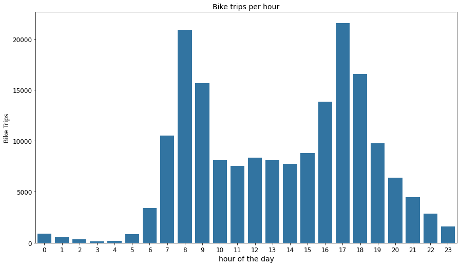

## Distribution of Bike trips per day.

bike trips distributed on all days of the week, least amount of the trips were on weekends ( sundays, saturdays), as most of people don't have to go to work on weekends and students don't go school or college.

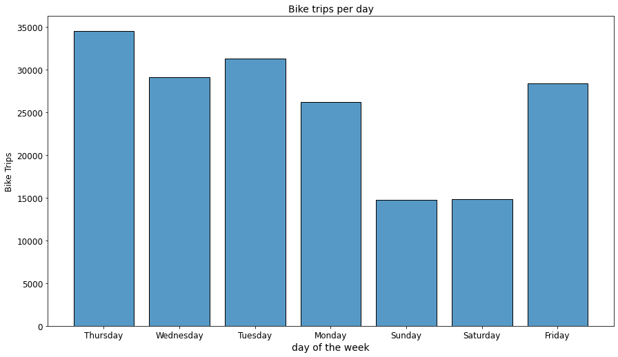

## Bike Trips for Customers and Subscribers

customers spend more time in their trips on average, we can see that most subsrcribers trips are nearly of the same duration, but for subscibers the trip duration distribution is much wider as they spend different amount of time in their trips.

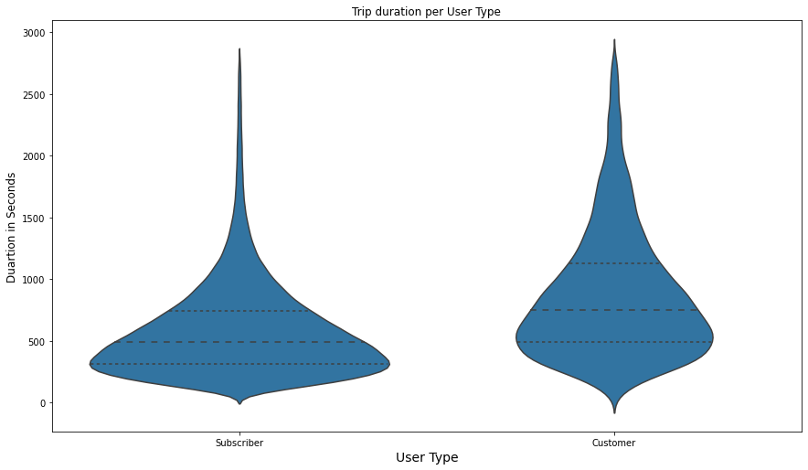

## Duration of Trip vs Member Age

there is a weak positive realtion between member age and duration of the trip, people who are 30 years old spent more time in the trips

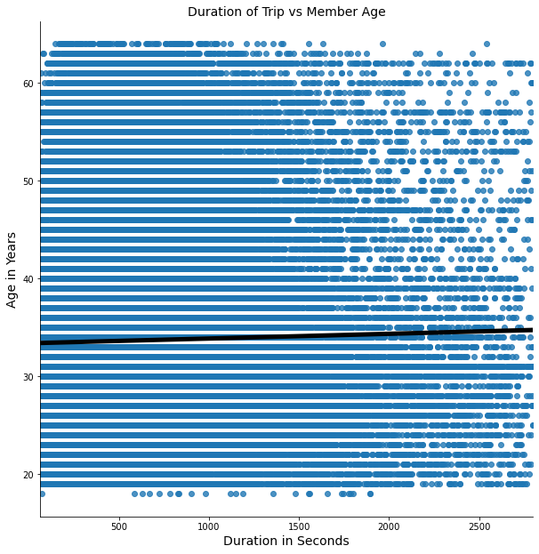

## trip duration for members in bike share program

people who aren't members in (bike_share_program_for_all) are spending much time on their trips in average cmpared to people who are members in the program.

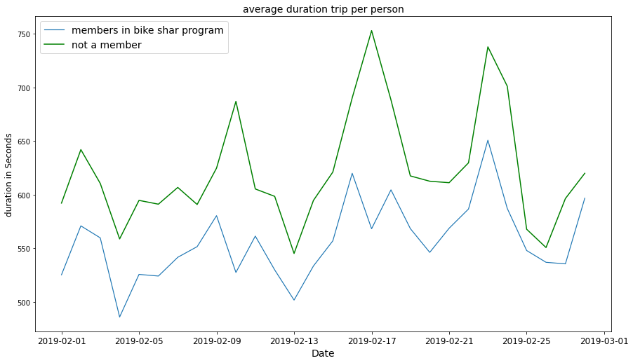

## trips Duration over the day per gender

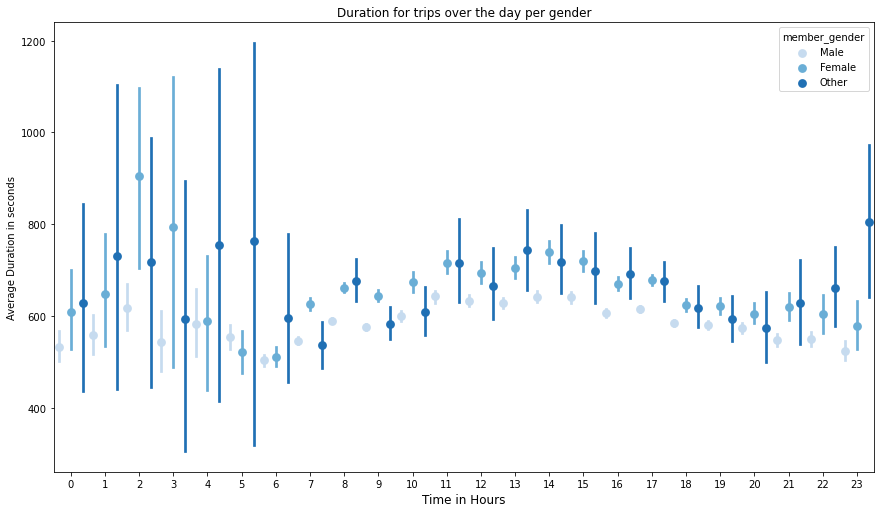

## Trips Duration for Different ages per User Type

average trips duration for customers is higher than average trip duration for subscribers,people of different ages spend nearly the same time per user type, people who are 18 years old spend much time in trips.

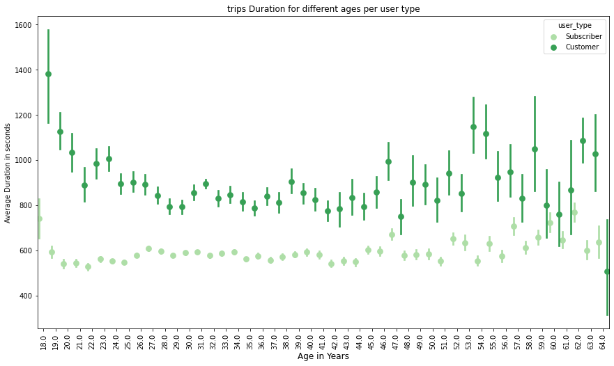